# R Notebook

Alustava analyysi:

```r
## Data manipulation

## Set working directory
dir <- here::here()
setwd(dir)

## Load the csv files
data_raw <- read.csv("data/2017-05-29-tyojaterveys-opendata-COMPLETE.csv", sep = "")
meta_raw <- read.csv("data/2017-05-29-tyojaterveys-metadata-LARGE.csv", sep = "")

## Metadata transformation
meta <- meta_raw %>%
  select(questionID, columnNameLong, codeKey) %>%
  na.omit()

meta <- meta %>%
  separate(codeKey, sep = ",", into = paste0("codeKey", seq_len(max(str_count(meta$codeKey, ",")) + 1))) %>%
  gather(key = "codeKey", value = "answer", -questionID, -columnNameLong) %>%
  separate(answer, sep = "=", into = c("answer", "descr")) %>%
  select(-codeKey)

## Data transformation
data <- data_raw %>%
  gather(key = "questionID", value = "answer", -id, -vuosi)

## Join with actual data with metadata
data <- left_join(data,  meta %>% select(questionID, columnNameLong), by = c("questionID" = "questionID")) %>%
  distinct() %>%
  na.omit()

data <- left_join(data, meta %>% select(questionID, answer, descr), by = c("questionID" = "questionID", "answer" = "answer"))

## Some of the answer need to be edited manually
data$descr <- ifelse(data$questionID == "t11", data$answer, data$descr)
data$descr <- ifelse(data$questionID == "tol2008", data$answer, data$descr)

## Last NA -value omit
data <- na.omit(data)

## Rename variables
colnames(data) <- c("person_id", "year", "question_id", "answer_id", "question", "answer")
```

Katsotaan yksittäiset kysymykset

```r
questions <- unique(data$question)
questions
```

```
  [1] "sukupuoli"                                "ikaLuokka"                                "tyottomyydenTodennakoisyys"
  [4] "tyopaikanTaloustilanne"                   "toimialaLuokitus"                         "viikonLoppuTyoPerKK"
  [7] "etaTyoFreq"                               "tyoaikaJoustoFreq"                        "tyoMuutoksetViime3v"
 [10] "tyoIlmanKuivuus"                          "tyoIlmanTunkkaisuus"                      "tyoMeluEsiintyvyys"
 [13] "tyoKovaMelu"                              "tyoTarinaEsiintyvyys"                     "tyoKemikaalitLiuottimet"
 [16] "tyoKemikaalitPesuDesinfiointi"            "tyoAltistusHitsausJuotos"                 "tyoAltistusKaasut"
 [19] "tyoAltistusPoly"                          "altistusTupakansavu"                      "tyoKylmyysVetoisuus"
 [22] "tyoKuumuus"                               "tyoHuonoValaistus"                        "tyoAltistusHomeetArvio"
 [25] "tyoAltistusHomeet"                        "kemikaalienVaroitusMerkinnat"             "kemikaalienKayttoturvaTiedotteet"
 [28] "ergnomiaLaitteet"                         "fyysinenKuormitus"                        "henkinenKuormitus"
 [31] "tyÃ¶AsentoTyypillinen"                    "nostaminenKannattelu"                     "hankalatTyoasennotSelka"
 [34] "hankalatTyoasennotKadetYliHartiatason"    "hankalatTyoasennotKyykky"                 "hankalatTyoasennotKadetPuristusKierto"
 [37] "hankalatTyoasennotNiska"                  "hankalatTyoasennotToistuvaKasiliike"      "itLaitteetTietokone"
 [40] "itLaitteetTyostokone"                     "itLaitteetMuut"                           "itLaitteetKassapaate"
 [43] "itOhjelmatOmaksuminen"                    "tyoTapaturmaViim12kk"                     "uhkailuTyopaikalla"
```

[output cut: 36 more lines]

Turkitaan siis mielenterveyttä (tai henkistä jaksamista)

Olisiko target tällöin tyokykyHenkinen

Tsektaana mitä se pitää sisällään

```r
data2 <- data %>%
  filter(question == "tyokykyHenkinen")
data4 <- unique(data2$answer); data4
```

```
[1] "erittÃ¤in hyvÃ¤" "melko hyvÃ¤"     "keskinkertainen" "melko huono"     "EOS"             "erittÃ¤in huono" "EV"
```

Kuinka paljon vastauksia per vuosi

```r
table(data2$answer, data2$year)
```

```
                  1997 2000 2003 2006 2009 2012
  EOS                3    6    4    3    7    1
  erittÃ¤in huono    3    3    5    7    4    6
  erittÃ¤in hyvÃ¤  600  590  656  643  836  608
  EV                 0    0    0    1    1    1
  keskinkertainen  342  270  350  311  322  236
  melko huono       26   36   31   43   40   41
  melko hyvÃ¤     1162 1126 1280 1221 1145  934
```

Vastauksia näyttää olevan ihan okei… target voisi olla, että jos työkyky on melko huono/erittäin huono niin 1 ja muuten 0?

Luodaan muuttuja target_tyokykyHenkinen ja työstetään sitä data3:ssa

```r
data3 <- data_raw
data3$target_tyokykyHenkinen <- ifelse(data3$t13 %in% c("4", "5"), 1, 0)
```

Lisätty ensimmäinen target data3:seen

```r
table(data3$vuosi, data3$target_tyokykyHenkinen)
```

```
          0    1
  1997 2107   29
  2000 1992   39
  2003 2290   36
  2006 2179   50
  2009 2311   44
  2012 1780   47
```

Näyttää ok:lta

Toinen target

eli TyokykyFyysinen samalla logiikalla kuin henkinen

```r
data2 <- data %>%
  filter(question == "tyokykyFyysinen")
data4 <- unique(data2$answer); data4
```

```
[1] "erittÃ¤in hyvÃ¤" "melko hyvÃ¤"     "keskinkertainen" "melko huono"     "EOS"             "erittÃ¤in huono" "EV"
```

Kuinka paljon vastauksia per vuosi

```r
table(data2$answer, data2$year)
```

```
                  1997 2000 2003 2006 2009 2012
  EOS                1    3    4    4    6    3
  erittÃ¤in huono    7    7    9   13   12   15
  erittÃ¤in hyvÃ¤  772  722  858  787  960  637
  EV                 0    0    0    1    1    2
  keskinkertainen  342  266  377  314  320  276
  melko huono       41   37   30   49   50   46
  melko hyvÃ¤      973  996 1048 1061 1006  848
```

```r
data3$target_tyokykyFyysinen <- ifelse(data3$t12 %in% c("4", "5"), 1, 0)
```

Lisätty toinen target data3:seen

```r
table(data3$vuosi, data3$target_tyokykyFyysinen)
```

```
          0    1
  1997 2088   48
  2000 1987   44
  2003 2287   39
  2006 2167   62
  2009 2293   62
  2012 1766   61
```

Hyvältä näyttää sekin…

Kokeillaan vielä kolmas target, joka on tyokykyArvio

```r
data2 <- data %>%
  filter(question == "tyokykyArvio")
data4 <- unique(data2$answer); data4
```

```
 [1] "10" "8"  "9"  "7"  "6"  "5"  "4"  "88" "3"  "2"  "0"  "1"  "99"
```

Kuinka paljon vastauksia per vuosi

```r
table(data2$answer, data2$year)
```

```
     1997 2000 2003 2006 2009 2012
  0     3    5    7    5    5    6
  1     0    5    1    3    2    1
  10  402  312  371  313  359  314
  2     1    0    1    4    3   11
  3     3    3    4    7    4    2
  4     9   10    4   15   17   18
  5    35   29   35   31   37   36
  6    46   36   62   53   75   63
  7   255  231  317  292  258  220
  8   745  771  825  802  861  570
  88    7    2    3    3    4   16
  9   630  627  695  700  729  557
  99    0    0    1    1    1   13
```

```r
data3$target_tyokykyArvio <- ifelse(data3$t11 < 7, 1, 0)
```

```r
table(data3$vuosi, data3$target_tyokykyArvio)
```

```
          0    1
  1997 2039   97
  2000 1943   88
  2003 2212  114
  2006 2111  118
  2009 2212  143
  2012 1690  137
```

Tehään vielä target, jossa otetaan kaikki kolme aiempaa targettia huomioon

```r
data3$target_tyokyky <- ifelse(data3$target_tyokykyFyysinen == 1 | data3$target_tyokykyHenkinen == 1 | data3$target_tyokykyArvio == 1, 1, 0)
```

```r
table(data3$vuosi, data3$target_tyokyky)
```

```
          0    1
  1997 2001  135
  2000 1910  121
  2003 2186  140
  2006 2067  162
  2009 2177  178
  2012 1657  170
```

Selittäviä muuttujia nyt mukaan:

Ensimmäinen on sukupuoli

```r
data2 <- data %>%
  filter(question == "sukupuoli")
data4 <- unique(data2$answer); data4
```

```
[1] "mies"   "nainen"
```

```r
table(data2$answer, data2$year)
```

```
         1997 2000 2003 2006 2009 2012
  mies   1023 1057 1140 1130 1212  859
  nainen 1113  974 1186 1099 1143  968
```

Sukupoli ok, lisätään sellaisenaan

Toimiala voidaan lisätä mukaan jos vuosi 1997 pudotetaan pois. Tämä ok, tehdään niin

```r
data2 <- data %>%
  filter(question_id == "tol2008")
data4 <- unique(data2$answer); data4
```

```
 [1] "Z"       "G"       "M"       "F"       "Q"       "B,C"     "P"       "H"       "O"       "N"       "I"       "J"       "A"       "D,E,L,S" "K"
[16] "R"       "T"
```

```r
table(data2$answer, data2$year)
```

```
          1997 2000 2003 2006 2009 2012
  A          0  102  111  110  117   93
  B,C        0  422  435  440  444  201
  D,E,L,S    0  121  112  108  113  117
  F          0  112  130  150  171  117
  G          0  176  217  193  232  217
  H          0  137  148  127  137  114
  I          0   51   44   67   67   77
  J          0   92  114   89   98   61
  K          0   50   54   57   42   34
  M          0   90  140  115  138  100
  N          0   62   69   62   84   87
  O          0  133  105  113  120   78
  P          0  149  208  171  166  189
  Q          0  291  394  379  377  298
  R          0   40   35   41   48   44
  T          0    3    8    3    1    0
  Z       2136    0    2    4    0    0
```

Toimialoja T ja Z aika vähän… voisi pudottaa pois

Tsekataan tähän väliin, että kuinka monta vastausta per question_id

```r
table(data$question_id)
```

```
     b1 b16ylii b16yliv    b17d     b21     b22    b24d     b25     b26      e3      f1     f10    f10b   f11_1   f11_2   f11_3   f11_4     f14      f2     f3b
  12904    8504    8503      29   11008    5463     917    6411    5487    8722   12025   12025    6586   12891   11077   11074    6910    7748   12904   12024
     f6      f7      f8      f9      h1     h10     h11     h12     h13     h1t      h2      h3      h4      h5      h6      h7      h8     h9a     h9b     ika
  12025   12015    8722   12025   12904   12025   24318    6910    7858    7858   12904   12025   12025    8722    8722    8722   11077   10768    6586   12904
     j1     j10     j11     j12     j13     j14     j16    j16b     j18     j19      j2     j20    j21b     j22     j23     j24    j24b     j25     j26     j27
  12904    4709   12904    8722   12904   12904    8111    8533   11823   11823   12904   11042    7378   10970   10970   10297    8737   12450   11609   10820
    j28     j29     j30    j30b    j30c     j32     j35     j36     j37     j38     j3b      j4     j41     j42     j43      j7    k10a      k3      k4      k5
   2484   10805    2930    6586    6586   12904    7759    7789    5463    6586    7789   12904    6411    6411    4056    8722    6910    7547    3867    6898
     k6      k7      k8      k9     l10   l12_1   l12_2     l1a     l1b      l2   l20aa     l21     l22   l23_a   l23_b    l7ua     n2j      n4    n5u1    n6bu
  12904   12904   12853   11956   10106    5312    5312   12904    5661   10999   15362   10988   10989    7677    8479   10257    9863   19262   12025    4948
    n6u      n7     n7a     s1c     s1d      t1     t10     t11     t12     t13     t14     t15      t6   t6j_1  t6j_10  t6j_11  t6j_12  t6j_13  t6j_14  t6j_16
   4876   11951    3786    1720    1694   12889   11947   12904   12904   12904   12887    8737   12904    4601    4621    4691    4627    4593    4597    4586
 t6j_19  t6j_21  t6j_22  t6j_23  t6j_24  t6j_25  t6j_26  t6j_29   t6j_3   t6j_6   t6j_8   t6j_9      t8 tol2008      v1     v10   v11_1  v11_10  v11_13   v11_2
   4602    4599    4585    4625    4601    4594    4600    2357    4586    4589    4682    4621    4173   12904   12025   12904    3210    3210    3143    3210
  v11_3   v11_4   v11_5   v11_6   v11_7   v11_8   v11_9     v7a     v7b
   3211    3211    3211    3210    3209    3210    3210    5532    5532
```

Etätyö seuraavaksi

```r
data2 <- data %>%
  filter(question_id == "b24d")
data4 <- unique(data2$answer); data4
```

```
[1] "viikoittain"           "epÃ¤sÃ¤Ã¤nnÃ¶llisesti" "kuukausittain"         "harvemmin"             "EOS"
```

```r
table(data2$answer, data2$year)
```

```
                        2003 2006 2009 2012
  EOS                      0    2    0    1
  epÃ¤sÃ¤Ã¤nnÃ¶llisesti   45   58   61   32
  harvemmin               16   31   37   15
  kuukausittain           51   66   69   23
  viikoittain             98  134  132   46
```

Otetaan etätyöfreq mukaan. Muuta ei siihen liittyen löytynyt. Vastaukset näyttää olevan ok. Paitsi vastauksia ei näytä olevan kuin 2003 alkaen… Otetaan aluksi mukaan mutta jätetään pois myöhemmin jos vaikuttaa paljon. B24d näyttää sisältävän paljon NA arvoja… oletetaanko, että ne eivät tee etätöitä??

```r
## Tehdään muuttuja b24e eli etätyöFreq mutta ilman NA arvoja
data3$b24f <- ifelse(is.na(data3$b24d) == TRUE | data3$b24d == 8 | data3$b24d == 9, 0,  data3$b24d)
```

Seuraavaksi selittäväksi esimiestuki, katsotaan vastaukset:

```r
data2 <- data %>%
  filter(question_id == "j20")
data4 <- unique(data2$answer); data4
```

```
[1] "melko paljon"      "jonkin verran"     "erittÃ¤in paljon"  "EOS"               "melko vÃ¤hÃ¤n"     "erittÃ¤in vÃ¤hÃ¤n" "EV"                "ei esimiestÃ¤"
```

```r
table(data2$answer, data2$year)
```

```
                    1997 2000 2003 2006 2009 2012
  ei esimiestÃ¤        0    0    0    0   24    0
  EOS                 30   39   39    6    3   11
  erittÃ¤in paljon   385  436  442  394  524  376
  erittÃ¤in vÃ¤hÃ¤n   92  117  101   77   84   49
  EV                   0    0    5    0    0    1
  jonkin verran      522  447  520  532  475  360
  melko paljon       624  570  750  671  734  593
  melko vÃ¤hÃ¤n      158  161  181  200  204  105
```

Myös johdon tuki olisi hyvä ottaa mukaan. Katsotaan siitäkin vastaukset

```r
data2 <- data %>%
  filter(question_id == "j35")
data4 <- unique(data2$answer); data4
```

```
[1] "jonkin verran"    "erittÃ¤in paljon" "melko paljon"     "ei lainkaan"      "hyvin vÃ¤hÃ¤n"    "EOS"              "EV"
```

```r
table(data2$answer, data2$year)
```

```
                   2003 2006 2009 2012
  ei lainkaan        53   58   64   35
  EOS                39   31   34   67
  erittÃ¤in paljon  319  291  447  317
  EV                  3    1    5    0
  hyvin vÃ¤hÃ¤n     240  221  235  140
  jonkin verran     638  639  619  444
  melko paljon      723  653  790  653
```

Seuraavaksi tiimityö

```r
data2 <- data %>%
  filter(question_id == "j16b")
data4 <- unique(data2$answer); data4
```

```
[1] "kyllÃ¤ pÃ¤Ã¤asiallisesti"   "ei ollenkaan"               "osittain tai tilapÃ¤isesti" "EOS"                        "EV"
```

```r
table(data2$answer, data2$year)
```

```
                             2000 2003 2006 2009 2012
  ei ollenkaan                400  502  300  410  309
  EOS                           8    9   10    4   31
  EV                            0    0    0   41    1
  kyllÃ¤ pÃ¤Ã¤asiallisesti    593  812  955  893  571
  osittain tai tilapÃ¤isesti  597  583  535  604  365
```

Vertaistuki myös mukaan

```r
data2 <- data %>%
  filter(question_id == "j19")
data4 <- unique(data2$answer); data4
```

```
[1] "melko vÃ¤hÃ¤n"     "jonkin verran"     "melko paljon"      "erittÃ¤in paljon"  "erittÃ¤in vÃ¤hÃ¤n" "EOS"               "EV"
```

```r
table(data2$answer, data2$year)
```

```
                    1997 2000 2003 2006 2009 2012
  EOS                 11   21   10    8   12    9
  erittÃ¤in paljon   612  685  709  686  867  655
  erittÃ¤in vÃ¤hÃ¤n   24   23   31   42   28   22
  EV                   0    0    3    0    3    3
  jonkin verran      420  353  442  415  340  243
  melko paljon       793  697  853  823  870  677
  melko vÃ¤hÃ¤n       84   57   73   98   74   47
```

Otetaan vielä mukaan ammatilliset kehitysmahdollisuudet eli j37

```r
data2 <- data %>%
  filter(question_id == "j37")
data4 <- unique(data2$answer); data4
```

```
[1] "heikot"       "hyvÃ¤t"       "jonkinlaiset" "EOS"          "EV"
```

```r
table(data2$answer, data2$year)
```

```
               2006 2009 2012
  EOS            14   10   22
  EV              0    0    2
  heikot        388  387  129
  hyvÃ¤t        935 1044  341
  jonkinlaiset  892  914  385
```

Ei otetakaan mukaan sillä vähän vuosia!

Katsotaan työterveyshuoltoa

```r
data2 <- data %>%
  filter(question_id == "l1a")
data4 <- unique(data2$answer); data4
```

```
[1] "ei"     "kyllÃ¤" "EOS"    "EV"
```

```r
table(data2$answer, data2$year)
```

```
         1997 2000 2003 2006 2009 2012
  ei      338  249  300  308  321  245
  EOS      25   26   23   26   10   39
  EV        0    0    0    1    1    2
  kyllÃ¤ 1773 1756 2003 1894 2023 1541
```

Otetaan se mukaan mutta filtteröidään myös

Iän simulointi

```r
## Age simulation function
age_simulation <- function(x){
  if(x == "1"){
    round(runif(1, min = 24, max = 34), digits = 1)
  } else if(x == "2") {
    round(runif(1, min = 34, max = 44), digits = 1)
  } else if(x == "3") {
    round(runif(1, min = 44, max = 54), digits = 1)
  } else {
    round(runif(1, min = 54, max = 64), digits = 1)
  }
}

data3$ika_simuloitu <- sapply(data3$ika, age_simulation)
```

Final datasetti

```r
data_final <- data3 %>%
  filter(vuosi > 2002) %>% #Vuosi 1997 pudettu pois toimialan vuoksi. Vuoden 1997 ja 2000 pudotettu pois etätyön vuoksi
  filter(j20 < 6) %>% # Eli tässä otetaan pois kaikki kenellä ei ole esimiestä tai ei osaa vastata
  filter(j35 < 6) %>% # Otetaan tässä pois ne jotka eivät osaa vastata JohdonHuolenpitoon
  filter(j19 < 6) %>% # Otetaan vertaistuesta pois taas ne jotka eivät osaa sanoa
  filter(j16b < 6) %>% # Otetaan tiimityöstä pois jotka eivät vastaa/osaa sanoa
  filter(l1a < 3) %>% # Otetaan pois jotka eivät vastaa/osaa sanoa
  select(id,
         vuosi,
         b1, #Sukupuoli
         tol2008, #Toimiala
         b24f, #Etätyö (itse tehty muuttuja, ei löydy metadatasta (pitää siis lisätä sinne))
         ika, # Otetaan mukaan ihan tarkastuksen vuoksi
         ika_simuloitu, # simuloitu ika, itse tehty, ei metaa
         j20, #esimiestuki, ei vielä muokattu, vain filtteröity
         j35, #johdonHuolenpito, ei muoktattu, vain filtteröity
         j16b, #tiimityö, ei muokattu, filtteröity
         j19, # vertaistuki
         l1a, # onko työterveyttä dummy
         target_tyokykyHenkinen,
         target_tyokykyFyysinen,
         target_tyokykyArvio,
         target_tyokyky
         ) %>%
  mutate(j20j35 = j20 + j35) %>% # uusi muuttuja johdon huolenpidosta ja esimiestuesta. Aika vähän arvoja ääripäässä eli 8, 9.. pitäisikö yhdistää??
  mutate(j20j35j19 = j20 + j35 + j19) %>% # mukana myös vertaistuki
  mutate(j20j35mod = ifelse(j20j35 > 7, 8, j20j35)) %>% # yhdistetty j20j35 ja korvattu ääriarvot, tämä hyvä selittäjä
  mutate(j20j35j19mod = ifelse(j20j35j19 > 9, 10, j20j35j19)) %>% # yhdistetty j20j35 ja korvattu ääriarvot, tämä hyvä selittäjä
  mutate(b24fmod = ifelse(b24f == 0, 0, 1))  # Tehdään etätyödummy muuttuja
```

```r
model <- survfit(Surv(ika_simuloitu, target_tyokyky) ~ j16b, data = data_final)

ggsurvplot(model,
           data = data_final,
           xlim = c(35, 64),
           ylim = c(0.2, 1)
          )
```

[output not shown]

```
Removed 1 row(s) containing missing values (geom_path).Removed 1 row(s) containing missing values (geom_path).
```

```r
model <- survfit(Surv(ika_simuloitu, target_tyokykyFyysinen) ~ j20j35mod, data = data_final)

ggsurvplot(model,
           data = data_final,
           xlim = c(35, 62),
           ylim = c(0.2, 1)
          )
```

[output not shown]

```
Removed 1 row(s) containing missing values (geom_path).Removed 1 row(s) containing missing values (geom_path).
```

```r
model <- survfit(Surv(ika_simuloitu, target_tyokykyHenkinen) ~ j20j35mod, data = data_final)

ggsurvplot(model,
           data = data_final,
           xlim = c(35, 62),
           ylim = c(0.2, 1)
          )
```

[output not shown]

```
Removed 1 row(s) containing missing values (geom_path).Removed 1 row(s) containing missing values (geom_path).
```

```r
model <- survfit(Surv(ika_simuloitu, target_tyokyky) ~ j20j35mod, data = data_final)

ggsurvplot(model,
           data = data_final,
           xlim = c(35, 62),
           ylim = c(0.2, 1)
          )
```

[output not shown]

```
Removed 1 row(s) containing missing values (geom_path).Removed 1 row(s) containing missing values (geom_path).
```

```r
model <- survfit(Surv(ika_simuloitu, target_tyokyky) ~ j19, data = data_final)

ggsurvplot(model,
           data = data_final,
           xlim = c(35, 64),
           ylim = c(0.2, 1)
          )
```

[output not shown]

```r
model <- survfit(Surv(ika_simuloitu, target_tyokyky) ~ j20j35j19mod, data = data_final)

ggsurvplot(model,
           data = data_final,
           xlim = c(35, 62),
           ylim = c(0.2, 1),
           #surv.median.line = "hv",
           #conf.int = TRUE
          )
```

[output not shown]

```
Removed 1 row(s) containing missing values (geom_path).Removed 1 row(s) containing missing values (geom_path).
```

```r
model <- survfit(Surv(ika_simuloitu, target_tyokykyFyysinen) ~ j20j35j19mod, data = data_final)

ggsurvplot(model,
           data = data_final,
           xlim = c(35, 62),
           ylim = c(0.2, 1)
          )
```

[output not shown]

```r
model <- survfit(Surv(ika_simuloitu, target_tyokykyHenkinen) ~ j20j35j19mod, data = data_final)

ggsurvplot(model,
           data = data_final,
           xlim = c(35, 62),
           ylim = c(0.2, 1)
          )
```

[output not shown]

```
Removed 1 row(s) containing missing values (geom_path).Removed 1 row(s) containing missing values (geom_path).
```

```r
model <- survfit(Surv(ika_simuloitu, target_tyokyky) ~ l1a, data = data_final)

ggsurvplot(model,
           data = data_final,
           xlim = c(35, 64),
           ylim = c(0.2, 1)
          )
```

[output not shown]

Seuraavaksi voisi kokeilla vielä tehdä surv table jossa p arvot

```r
res.cox <- coxph(Surv(ika_simuloitu, target_tyokyky) ~ j20 + j35 + j19 + b1, data = data_final)
res.cox
```

```
Call:
coxph(formula = Surv(ika_simuloitu, target_tyokyky) ~ j20 + j35 +
    j19 + b1, data = data_final)

        coef exp(coef) se(coef)      z        p
j20  0.20623   1.22904  0.04887  4.220 2.44e-05
j35  0.44130   1.55473  0.05036  8.764  < 2e-16
j19 -0.01021   0.98984  0.05301 -0.193    0.847
b1  -0.08702   0.91666  0.09579 -0.909    0.364

Likelihood ratio test=156.6  on 4 df, p=< 2.2e-16
n= 6407, number of events= 443
```

```
The `data` argument is not provided. Data will be extracted from model fit.
```

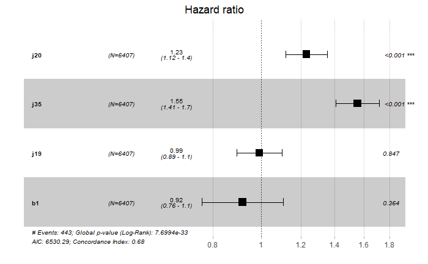

```r
ggforest(res.cox)
```

```r
table(data_final$target_tyokykyHenkinen, data_final$target_tyokykyFyysinen)
```

```
       0    1
  0 6146  128
  1  111   22
```

Saadaanko ääkköset pois??